# Visualizing with Matplotlib and Seaborn

### Use of AI: can be used, but must be reported.

### AI shall not be used to complete the whole assignment.

```python
# Take necessary libraries in use.
import pandas as pd
import matplotlib.pyplot as plt
import seaborn as sns
```

## Load the penguins dataset and check info

```python
penguins = sns.load_dataset("penguins")
```

```python
penguins.info()
```

```
<class 'pandas.DataFrame'>
RangeIndex: 344 entries, 0 to 343
Data columns (total 7 columns):
 #   Column             Non-Null Count  Dtype
---  ------             --------------  -----
 0   species            344 non-null    str
 1   island             344 non-null    str
 2   bill_length_mm     342 non-null    float64
 3   bill_depth_mm      342 non-null    float64
 4   flipper_length_mm  342 non-null    float64
 5   body_mass_g        342 non-null    float64
 6   sex                333 non-null    str
dtypes: float64(4), str(3)
memory usage: 18.9 KB
```

## Tasks

### Task 0: Drop missing values and check they were dropped.

```python
# Your code here
penguins = penguins.dropna()
penguins.info()
```

```
<class 'pandas.DataFrame'>
Index: 333 entries, 0 to 343
Data columns (total 7 columns):
 #   Column             Non-Null Count  Dtype
---  ------             --------------  -----
 0   species            333 non-null    str
 1   island             333 non-null    str
 2   bill_length_mm     333 non-null    float64
 3   bill_depth_mm      333 non-null    float64
 4   flipper_length_mm  333 non-null    float64
 5   body_mass_g        333 non-null    float64
 6   sex                333 non-null    str
dtypes: float64(4), str(3)
memory usage: 20.8 KB
```

### Complete the following tasks using Matplotlib and Seaborn.

- Your task is to replicate the given plots using the penguins data.
- Plots are in Plots.html.
- You need to get all the labels, titles etc. elements to the plot.
- The size of the plot does not need to be exactly the same. As long as your plot is readable, it is fine.
- You do not need to guess the used colors, so feel free to choose the color palette you like. You can test different color palettes for different plots if you wish. https://seaborn.pydata.org/tutorial/color_palettes.html
- Use the hints and further instructions whenever given.
- Please do not give the plot to AI and ask for the code, but try to figure out yourself, what the plot is and how to construct it and what are the different elements called.
- Also try to understand what kind of information the plot tells.
- Self-made good try is better than perfect AI-generated outcome! Self-made good try is also better than empty task.
- Try to construct plot piece-by-piece. You do not need to get all the elements there at once. Run your code frequently and add things.

### Before asking AI, try to find answers from these quick start guides and tutorials (and check also previous assignments for hints):

Matplotlib quick start guide: https://matplotlib.org/stable/users/explain/quick_start.html

Seaborn introduction (especially parts about scatterplots and histograms): https://seaborn.pydata.org/tutorial/introduction.html

Seaborn tutorial: https://seaborn.pydata.org/tutorial/function_overview.html

### Task 1: Replicate the plot (SEE PLOTS FROM Plots.html).

- Hint: hue="species"

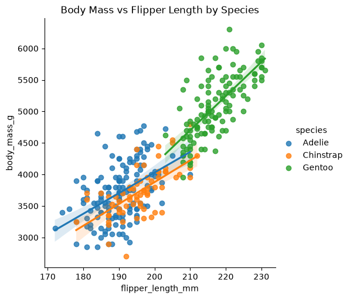

```python
sns.lmplot(data=penguins, x="flipper_length_mm", y="body_mass_g", hue="species")
plt.xlabel('flipper_length_mm', fontsize=10)
plt.ylabel('body_mass_g', fontsize=10)
plt.title("Body Mass vs Flipper Length by Species", fontsize=12)
plt.show()
```

### Task 2: Replicate the plot.

- Hint: kde=True

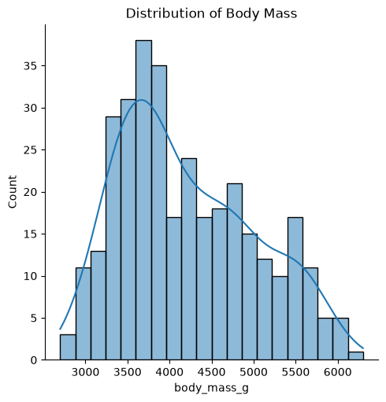

```python
sns.displot(data=penguins, x="body_mass_g", bins = 20, kde=True)
plt.xlabel('body_mass_g', fontsize=10)
plt.ylabel('Count', fontsize=10)
plt.title("Distribution of Body Mass", fontsize=12)
plt.show()
```

### Task 3: Replicate the plot.

- Hint: hue="species"
- Hint: plt.figure(figsize=(8, 5))

```
<function matplotlib.pyplot.show(close=None, block=None)>
```

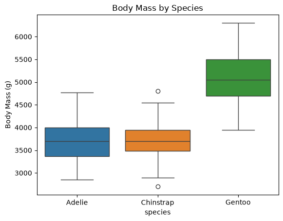

```python
sns.boxplot(data=penguins, x='species',y='body_mass_g',hue="species")
plt.ylabel('Body Mass (g)',fontsize=10)
plt.title('Body Mass by Species', fontsize=12)
plt.show
```

### Task 4: Replicate the plot (it is a violin plot)

- Hint: sns.violinplot()
- Hint: hue="species"
- Find out, what does a violin plot tell (so that you understand the purpose and can read the plot).

```
<function matplotlib.pyplot.show(close=None, block=None)>
```

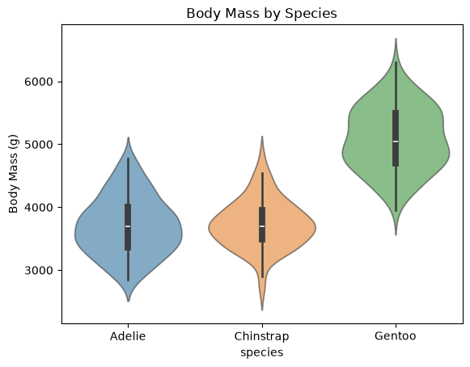

```python
sns.violinplot(data=penguins, x='species',y='body_mass_g',hue="species", alpha=0.6)
plt.ylabel('Body Mass (g)',fontsize=10)
plt.title('Body Mass by Species', fontsize=12)
plt.show
```

### Task 5: Replicate the plot.

- Hint: bins=15
- Hint: alpha=0.6
- Hint: hue="species"

```
<function matplotlib.pyplot.show(close=None, block=None)>
```

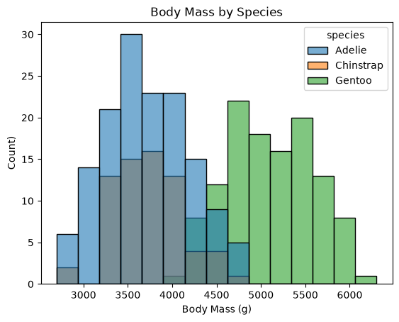

```python
sns.histplot(data=penguins, x='body_mass_g',hue="species", bins=15, alpha=0.6)
plt.xlabel('Body Mass (g)',fontsize=10)
plt.ylabel('Count)',fontsize=10)
plt.title('Body Mass by Species', fontsize=12)
plt.show
```

### Task 6: Replicate the plot.

- Hint: hue="species"

```
<function matplotlib.pyplot.show(close=None, block=None)>
```

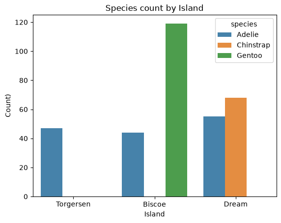

```python
sns.countplot(data=penguins, x='island',hue="species", alpha=0.9)
plt.xlabel('Island',fontsize=10)
plt.ylabel('Count)',fontsize=10)
plt.title('Species count by Island', fontsize=12)
plt.show
```

### Task 7: Replicate the plot.

- Hint: sns.pairplot()
- Hint: hue="species"

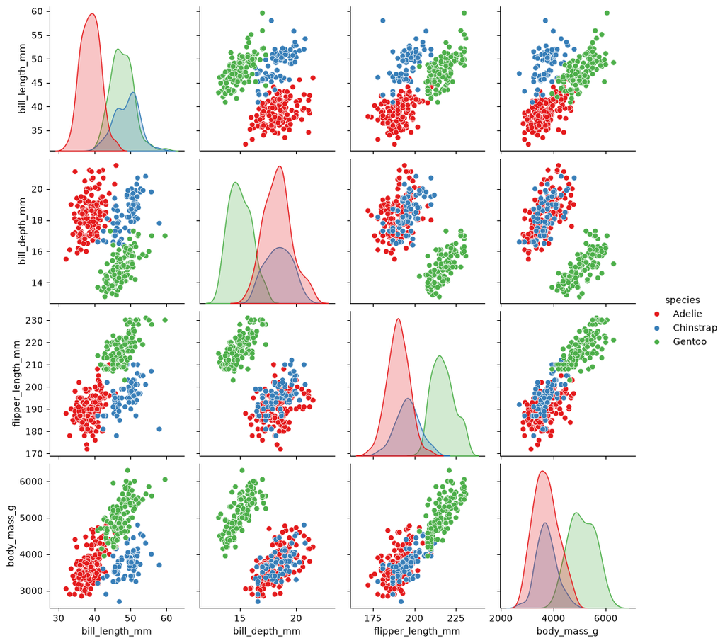

```python
sns.pairplot(data=penguins, hue="species",palette="Set1")
```

### Task 8: Explain the code and plot.

- Use the given code, no need to change it
- Figure out, what does correlation mean.
- Explain the code.
- Figure out, how to read the heatmap. Why is there always 1 (or 1.00) on the diagonal? What do the colors indicate?

#### **ANSWER TO TASK 8 QUESTIONS:**

##### 1. CORRILATION:

- Coorelation means there is a relation between the the variables: when one variable changes, it will lead to the change to the other variable in the same direction or opposite direction.

##### 2. EXPLAIN THE CODE:

- See comments in the below Code.

##### 3. HOW TO READ THE HEATMAP:

- The color is associated with the numbers
- The number is from -1 to +1.
  - The closer to number 1, the more correlated, which means the 2 variables are likely to move together ("Positive Correlation").
  - The closer to 0, the less correlated they are ("No Correlation").
  - The closer to -1, the more correlated, BUT they are moving in an opposite direction ("Negative correlation" or "Inverse correlation").
- The number 1 on the diagonal is where x = y = same variable, then naturally they move together, since they are the same one variable.

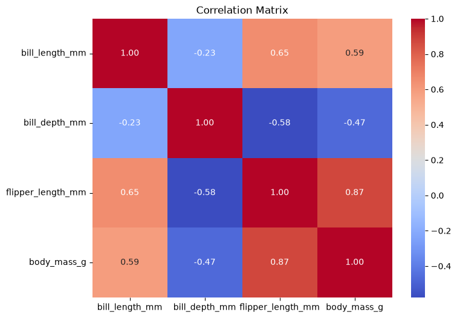

```python
corr = penguins.select_dtypes("number").corr() # Plot a Correlation table/matrix for all "number" datatype

plt.figure(figsize=(8, 6)) # Define the size of the correlation table

sns.heatmap(            # Create a heatmap in the table, showing the level of correlation with color density.
    corr,
    annot=True, # Plot the numbers in each cell of the table
    cmap="coolwarm",  # color map is coolwarm: red - hot; blue - cool.
    fmt=".2f" # format of numbers with decimal =2.
)

plt.title("Correlation Matrix") # Plot the table with Title "Correlation Matrix"

plt.show() # Show the table
```

### Task 9 CODING / REPLICATING THE PLOT IS VOLUNTARY. If you do not code, at least try to understand the plot.

- Hint: sns.scatterplot()
- Hint: hue="species"
- Hint: use size and sizes parameters.

```
<function matplotlib.pyplot.show(close=None, block=None)>
```

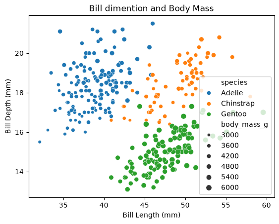

```python
sns.scatterplot(penguins, x='bill_length_mm',y='bill_depth_mm',hue="species",size="body_mass_g")
plt.xlabel('Bill Length (mm)',fontsize=10)
plt.ylabel('Bill Depth (mm)',fontsize=10)
plt.title('Bill dimention and Body Mass', fontsize=12)
plt.show
```

### Task: AI statement

- Describe here, how did you use AI in this assignment: Explainaiton of the code

### Task return

- File > Save and Export Notebook As > HTML
- Then take a look the produced HTML that it looks ok and readable
- Return to Itslearning, only the html document is returned, *not the .ipynb